# Zadanie ElasticSearch/PostgreSQL

> Wszystkie zaprezentowane poniżej tabele powstały za pomocą strony CsvToMarkdownTable. Tabele zostały zrzucone do plików .csv za pomocą komendy COPY zaprezentowanej w rozdziale “Zrzut mniejszej bazy” i przy użyciu powyższej strony przekonwertowane do tabel w Markdown.

### Przedstawienie danych

Zbiór podzielony jest na 2 pliki .csv: questions.csv oraz question_tags.csv.

#### Plik questions.csv

Plik posiada 17,203,824 rekordów oraz zajmuje około 883MB.

```sql
postgres=# SELECT * FROM import.questions LIMIT 1;

----------
Time: 0.418
```

| id | creationdate | closeddate | deletiondate | score | owneruserid | answercount |
| --- | --- | --- | --- | --- | --- | --- |
| 1084626 | 2009-07-05 18:51:55+02 | NA | NA | 2 | 51649 | 4 |

- **id** - id pytania
- **creationdate** - data utworzenia pytania
- **closeddate** - data zamknięcia pytania lub “NA” w przypadku braku zamknięcia
- **deletiondate** - data usunięcia pytania lub “NA” w przypadku ciągłego istnienia
- **score** - wewnętrzny system oceniania użytkowników StackOverflow
- **owneruserid** - id użytkownika, który umieścił dane pytanie
- **answercount** - ilość odpowiedzi przez innych użytkowników na dane pytanie

#### Plik question_tags.csv

Plik posiada 50,576,842 rekordów oraz zajmuje około 864MB.

```sql
postgres=# SELECT * FROM import.question_tags LIMIT 2;

----------
Time: 0.769 ms
```

| id | tag |
| --- | --- |
| 404484 | stylesheet |
| 404491 | javascript |

- **id** - identyfikator pytania z questions.csv
- **tag** - dany tag pytania

### Zrzut mniejszej bazy

Ponieważ bazy danych zajmują dużo miejsca na dysku, została przygotowana mniejsza wersja baz i zrzucona do plików .csv jako przykładowy zbiór pierwszych 100000 rekordów. Pragnę jednak zauważyć, że wszystkie operacje zostały wykonane na normalnym zbiorze danych - w związku z tym czasy wykonania zaprezentowane poniżej są o wiele dłuższe niż na danych testowych.

```sql
postgres=# COPY(SELECT * FROM import.question_tags LIMIT 100000) to 'D:\question_tags_small.csv' with CSV HEADER;

----------
Time: 125.215 ms
```

```sql
postgres=# COPY(SELECT * FROM import.questions LIMIT 100000) to 'D:\questions_small.csv' with CSV HEADER;

----------
Time: 142.078 ms
```

### PostgreSQL

1. Import danych - dane zostały zaimportowane do bazy danych PostgreSQL za pomocą programu pgfutter. Ponieważ baza danych została stworzona tylko na potrzeby zadania, przyjmujemy dużo wartości domyślnych dla bazy danych postgresql, więc większość argumentów można pominąć:

```bash
> pgfutter_windows_amd64.exe --pass <haslo> --table "questions" csv questions.csv

 861.87 MB / 861.87 MB [================================================================================] 100.00% 1m15s
17203824 rows imported into import.questions
```

```bash
>pgfutter_windows_amd64.exe --pass <haslo> --table "question_tags" csv question_tags.csv

 843.59 MB / 843.59 MB [================================================================================] 100.00% 1m27s
50576842 rows imported into import.question_tags
```

Całość zajeła 2 minuty i 42 sekundy.

2. Uruchomienie zliczania czasu przez PostgreSQL

```sql
postgres=# \timing on

Timing is on.
```

3. Obliczenie ilości wierszy dla obu tabel:

```sql
postgres=# SELECT COUNT(*) FROM import.questions;
  count
----------
 17203824

----------
Time: 14919.530 ms
```

```sql
postgres=# SELECT COUNT(*) FROM import.question_tags;
  count
----------
 50576842

----------
Time: 15917.783 ms
```

4. Konwersja daty i godziny na jedną strefę czasową:

```sql
postgres=# UPDATE import.questions SET creationdate = to_timestamp(creationdate, 'YYYY-MM-DD HH24:MI:SS');
----------
update 17203824 rows

Time: 147052.636 ms
```

Nie chcemy, aby zmieniano datę i czas niezamkniętym lub nieusuniętym pytaniom:

```sql
postgres=# UPDATE import.questions SET closeddate = to_timestamp(closeddate, 'YYYY-MM-DD HH24:MI:SS')
WHERE closeddate != 'NA';
----------
update 1724928 rows

Time: 60414.239 ms
```

```sql
postgres=# UPDATE import.questions SET deletiondate = to_timestamp(deletiondate, 'YYYY-MM-DD HH24:MI:SS')
WHERE deletiondate != 'NA';
---------
update 3963261 rows

Time: 78296.052 ms
```

5. Podstawowe agregacje
- Trzy najczęściej zadawane tagi:

```sql
postgres=# SELECT tag, count(*) AS tag_count FROM import.question_tags GROUP BY 1 ORDER BY tag_count DESC LIMIT 3;

Time: 9733.076 ms
```

| tag | tag_count |
| --- | --- |
| javascript | 1649631 |
| java | 1563820 |
| php | 1365600 |

- 10 pytań, które miały najdłuższy czas oczekiwania na udzielenie zadowalającej odpowiedzi:

```sql
postgres=# SELECT *, age(closeddate::timestamp, creationdate::timestamp) as open_since FROM import.questions WHERE closeddate != 'NA' ORDER BY open_since DESC LIMIT 10;

Time: 37800.120 ms
```

[output not shown]

```sql
postgres=# COPY(SELECT *, age(closeddate::timestamp, creationdate::timestamp) as open_since
FROM import.questions JOIN import.question_tags on import.questions.id = import.question_tags.id
WHERE closeddate != 'NA' ORDER BY open_since DESC LIMIT 10) to 'D:\unanswered_tags.csv' with CSV HEADER;

Time: 27222.711 ms
```

| id | creationdate | closeddate | deletiondate | score | owneruserid | answercount | id | tag | open_since |
| --- | --- | --- | --- | --- | --- | --- | --- | --- | --- |
| 9435 | 2008-08-13 03:23:55+02 | 2017-02-05 15:27:28+01 | NA | 5 | 648 | 8 | 9435 | responsive-design | 8 years 5 mons 23 days 12:03:33 |
| 9435 | 2008-08-13 03:23:55+02 | 2017-02-05 15:27:28+01 | NA | 5 | 648 | 8 | 9435 | mobile | 8 years 5 mons 23 days 12:03:33 |
| 9435 | 2008-08-13 03:23:55+02 | 2017-02-05 15:27:28+01 | NA | 5 | 648 | 8 | 9435 | wml | 8 years 5 mons 23 days 12:03:33 |
| 9435 | 2008-08-13 03:23:55+02 | 2017-02-05 15:27:28+01 | NA | 5 | 648 | 8 | 9435 | html | 8 years 5 mons 23 days 12:03:33 |
| 9435 | 2008-08-13 03:23:55+02 | 2017-02-05 15:27:28+01 | NA | 5 | 648 | 8 | 9435 | wap | 8 years 5 mons 23 days 12:03:33 |
| 2364 | 2008-08-05 14:14:36+02 | 2017-01-21 21:26:46+01 | NA | 14 | NA | 8 | 2364 | sqa | 8 years 5 mons 16 days 07:12:10 |
| 2364 | 2008-08-05 14:14:36+02 | 2017-01-21 21:26:46+01 | NA | 14 | NA | 8 | 2364 | tdd | 8 years 5 mons 16 days 07:12:10 |
| 2364 | 2008-08-05 14:14:36+02 | 2017-01-21 21:26:46+01 | NA | 14 | NA | 8 | 2364 | software-engineering | 8 years 5 mons 16 days 07:12:10 |
| 2364 | 2008-08-05 14:14:36+02 | 2017-01-21 21:26:46+01 | NA | 14 | NA | 8 | 2364 | unit-testing | 8 years 5 mons 16 days 07:12:10 |
| 5326 | 2008-08-07 21:16:31+02 | 2017-01-22 19:03:09+01 | 2017-01-27 17:28:31+01 | 7 | NA | 5 | 5326 | software-engineering | 8 years 5 mons 14 days 21:46:38 |

- Ilość pytań zadanych pomiędzy czerwcem a październikiem 2016 roku:

```sql
postgres=# SELECT COUNT(*) FROM import.questions
WHERE creationdate::timestamp BETWEEN '2016-06-01 00:00:00'::timestamp AND '2016-10-01 00:00:00'::timestamp;

  count
---------
 1049391

Time: 13853.401 ms
```

Po wywolaniu kilku zapytań z poprzednich, lat, udało się stworzyć poniższy wykres:

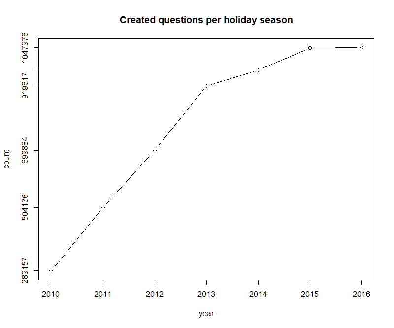

```r
count <- c(289157,504136,699884,919617,972940,1047976,1049391)
year <- c(2010,2011,2012,2013,2014,2015,2016)

plot(year,count, type="b", main="Created questions per holiday season", yaxt="n")
axis(2, at=count, labels=count)
```

### ElasticSearch

1. Import danych - postanowilam zapisac obie tabele w jednej i zrzucic je za pomoca PostgreSQL do formatu .json:

```sql
COPY (SELECT row_to_json(t) FROM (SELECT * FROM import.questions JOIN import.question_tags ON import.questions.id = import.question_tags.id LIMIT 1000000) as t) to 'D:\questions_small.json';
```

Niestety zrzucona baza byla zbyt wielka, aby na niej operowac - zajmowala jako plik .json az 9GB. Postanowilam zrzucic za pomoca powyzszego kodu tylko pierwsze milion rekordów (okolo 2% bazy). Eksport danych do pliku .json zajal 6 minut i 53 sekundy.

Nastepnie dodalam odpowiednie znaczniki .jsona do pliku i zaimportowalam go do ElasticSearch za pomoca bulk API:

```bash
> curl.exe -v -XPUT localhost:9200/so/_bulk --data-binary @questions_small.bulk
```

UPDATE: Ponieważ dodanie danych w taki sposób nie pozwolilo mi przeprowadzać żadnych agregacji liczbowych, postanowiłam usunąc mapping i zaimportować dane ponownie, specyfikując jakiego są typu:

```bash
> curl.exe -XDELETE "localhost:9200/so"

> curl.exe -XPUT localhost:9200/so -d "{\"mappings\":{\"questions\":{\"properties\":{\"answercount\":{\"type\":\"text\",\"fields\":{\"keyword\":{\"type\":\"keyword\",\"ignore_above\":256}}},\"closeddate\":{\"type\":\"text\",\"fields\":{\"keyword\":{\"type\":\"keyword\",\"ignore_above\":256}}},\"creationdate\":{\"type\":\"text\",\"fields\":{\"keyword\":{\"type\":\"keyword\",\"ignore_above\":256}}},\"deletiondate\":{\"type\":\"text\",\"fields\":{\"keyword\":{\"type\":\"keyword\",\"ignore_above\":256}}},\"id\":{\"type\":\"integer\",\"fields\":{\"keyword\":{\"type\":\"keyword\",\"ignore_above\":256}}},\"owneruserid\":{\"type\":\"text\",\"fields\":{\"keyword\":{\"type\":\"keyword\",\"ignore_above\":256}}},\"score\":{\"type\":\"integer\"},\"tag\":{\"type\":\"text\",\"fields\":{\"keyword\":{\"type\":\"keyword\",\"ignore_above\":256}}}}}}}"

> curl.exe -v -XPUT localhost:9200/so/_bulk --data-binary @questions_small.bulk
```

Zrobienie powyższej rzecz umożliwiło mapping API, dzięki któremu mogłam pobrać obecny mapping i zmienić go wedle uznania:

```bash
> curl.exe -XGET "localhost:9200/so/_mapping/questions"
```

Następnie potwierdziłam, czy faktycznie poprawnie zostało zaimportowanych 1000000 rekordów:

```bash
curl.exe -XGET localhost:9200/so/questions/_count

{"count":1000000,"_shards":{"total":5,"successful":5,"failed":0}}
```

2. Przykładowy wygląd elementu:

```bash
> curl.exe -XGET "localhost:9200/so/questions/_search?pretty=true&q=score:241"

{
  "_index" : "so",
  "_type" : "questions",
  "_id" : "AVr1R3c_QeECtexp6BHk",
  "_score" : 11.796741,
  "_source" : {
    "id" : "8722163",
    "creationdate" : "2012-01-04 04:51:14+01",
    "closeddate" : "NA",
    "deletiondate" : "NA",
    "score" : "241",
    "owneruserid" : "1129142",
    "answercount" : "3",
    "id" : "8722163",
    "tag" : "html"
  }
}
```

w _source sa zaimportowane dane z postgresql, opisane wyżej.

3. Przykładowe zapytania:
- ile jest pytań posiadających tag c#:

```bash
> curl.exe -XGET "localhost:9200/so/questions/_count?pretty=true&q=tag:c#"

{
  "count" : 54340,
  "_shards" : {
    "total" : 5,
    "successful" : 5,
    "failed" : 0
  }
}
```

- znalezienie najwyższego wyniku danego pytania przez użytkowników:

```bash
> curl.exe -XGET "localhost:9200/so/questions/_search?pretty" -d "{\"aggs\": {\"max_score\": {\"max\": {\"field\": \"score\"}}}}"

"aggregations" : {
  "max_score" : {
    "value" : 2922.0
  }
}
```

- ilość pytań na które nie udzielono jeszcze odpowiedzi:

```bash
> curl.exe -XGET "localhost:9200/so/questions/_count?pretty=true&q=answercount:NA"

{
  "count" : 102787,
  "_shards" : {
    "total" : 5,
    "successful" : 5,
    "failed" : 0
  }
}
```

### Podsumowanie

> Poniższe podsumowanie jest moją subiektywną opinią po wykonaniu projektu. Wartość 5 symbolizuje ocenę najlepszą - 1 natomiast ocenę najgorszą.

|  | PostgreSQL | ElasticSearch |
| --- | --- | --- |
| **Łatwość użycia** | 4/5 | 2/5 |
| **Szybkość wykonywania zapytań** | 3/5 | 5/5 |
| **Przystępność** | 4/5 | 1/5 |
| **Ilość zajmowanego miejsca** | 2/5 | 5/5 |
| **Jakość dokumentacji** | 4/5 | 2/5 |
| **Przetwarzanie wstępne** | Brak, program importujący | Potrzebne manualne konwersje |
| **Ocena końcowa** | 17/25 | 15/25 |
| **Czy poleciłabym** | Tak | Nie dla początkujących |